# **Loan Default Prediction**

### Decision Tree

```python
# Creating categorical variables
BAD_cols = ['BAD']

for col in BAD_cols:
    if col not in data.columns:  # Check for column existence
        print(f"Column '{col}' not found in DataFrame. Skipping...")
        continue

    print(f"\n** Percentage of Subcategories for Column: {col} **")
    print(data[col].value_counts(normalize=True, dropna=False).to_string())  # Include missing values
    print("-" * 70)  # Visual separator
```

```
** Percentage of Subcategories for Column: BAD **
0    0.800503
1    0.199497
----------------------------------------------------------------------
```

```python
dt = DecisionTreeClassifier(class_weight= "balanced", random_state= 1)  # Create a DecisionTreeClassifier instance
dt.fit(X_train, y_train)  # Fit the model on your training data
```

```
DecisionTreeClassifier(class_weight='balanced', random_state=1)
```

```python
# Checking performance on the training dataset
y_train_pred_dt = dt.predict(X_train)

metrics_score(y_train, y_train_pred_dt)
```

```
              precision    recall  f1-score   support

           0       1.00      1.00      1.00      3355
           1       1.00      1.00      1.00       817

    accuracy                           1.00      4172
   macro avg       1.00      1.00      1.00      4172
weighted avg       1.00      1.00      1.00      4172
```

```
              precision    recall  f1-score   support

           0       0.91      0.93      0.92      1416
           1       0.71      0.63      0.67       372

    accuracy                           0.87      1788
   macro avg       0.81      0.78      0.79      1788
weighted avg       0.86      0.87      0.87      1788
```

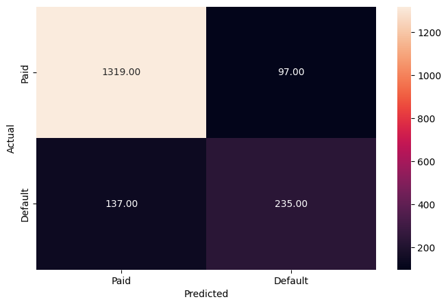

```python
# Checking performance on the test dataset
y_test_pred_dt = dt.predict(X_test)

metrics_score(y_test, y_test_pred_dt)
```

**Observations:**

Decision tree is giving us better slightly better recall results of 0.63

```python
dtree_test = model_performance_classification(dt,X_test,y_test)
dtree_test
```

|  | Precision | Recall | Accuracy | F1-score |
| --- | --- | --- | --- | --- |
| 1 | 0.806869 | 0.781609 | 0.869128 | 0.793069 |

### **Decision Tree - Hyperparameter Tuning**

- Hyperparameter tuning is tricky in the sense that **there is no direct way to calculate how a change in the hyperparameter value will reduce the loss of your model**, so we usually resort to experimentation. We'll use Grid search to perform hyperparameter tuning.
- **Grid search is a tuning technique that attempts to compute the optimum values of hyperparameters.**
- **It is an exhaustive search** that is performed on the specific parameter values of a model.
- The parameters of the estimator/model used to apply these methods are **optimized by cross-validated grid-search** over a parameter grid.

**Criterion {“gini”, “entropy”}**

The function to measure the quality of a split. Supported criteria are “gini” for the Gini impurity and “entropy” for the information gain.

**max_depth**

The maximum depth of the tree. If None, then nodes are expanded until all leaves are pure or until all leaves contain less than min_samples_split samples.

**min_samples_leaf**

The minimum number of samples is required to be at a leaf node. A split point at any depth will only be considered if it leaves at least min_samples_leaf training samples in each of the left and right branches. This may have the effect of smoothing the model, especially in regression.

You can learn about more Hyperpapameters on this link and try to tune them.

https://scikit-learn.org/stable/modules/generated/sklearn.tree.DecisionTreeClassifier.html

```python
# Choose the type of classifier
dtree_estimator = DecisionTreeClassifier(class_weight = "balanced", random_state = 1)

# Grid of parameters to choose from
parameters = {'max_depth': np.arange(2, 7),
              'criterion': ['gini', 'entropy'],
              'min_samples_leaf': [5, 10, 20, 25]
             }

# Type of scoring used to compare parameter combinations
scorer = metrics.make_scorer(recall_score, pos_label = 1)

# Run the grid search
gridCV = GridSearchCV(dtree_estimator, parameters, scoring = scorer, cv = 10)

# Fitting the grid search on the train data
gridCV = gridCV.fit(X_train, y_train)

# Set the classifier to the best combination of parameters
dtree_estimator = gridCV.best_estimator_

# Fit the best estimator to the data
dtree_estimator.fit(X_train, y_train)
```

```
DecisionTreeClassifier(class_weight='balanced', max_depth=6,
                       min_samples_leaf=20, random_state=1)
```

```
              precision    recall  f1-score   support

           0       0.96      0.83      0.89      3355
           1       0.56      0.86      0.68       817

    accuracy                           0.84      4172
   macro avg       0.76      0.85      0.79      4172
weighted avg       0.88      0.84      0.85      4172
```

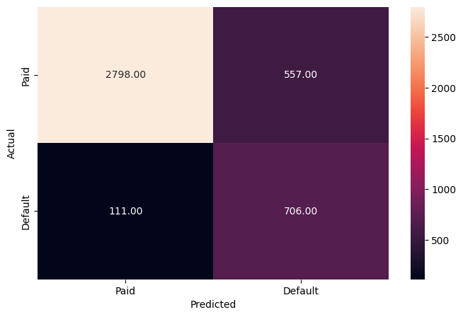

```python
# Checking performance on the training data
y_pred_train1 = dtree_estimator.predict(X_train)

metrics_score(y_train, y_pred_train1)
```

```
              precision    recall  f1-score   support

           0       0.94      0.82      0.88      1416
           1       0.54      0.79      0.64       372

    accuracy                           0.82      1788
   macro avg       0.74      0.81      0.76      1788
weighted avg       0.86      0.82      0.83      1788
```

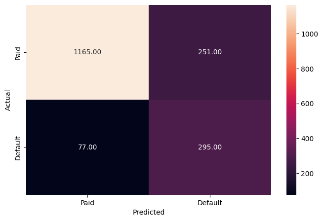

```python
# Checking performance on the testing data
y_pred_test1 = dtree_estimator.predict(X_test)

metrics_score(y_test, y_pred_test1)
```

**Observations:**

After tuning decision tree model is giving us much better recall results of 0.79

```python
dtree_tuned_test = model_performance_classification(dtree_estimator,X_test,y_test)
dtree_tuned_test
```

|  | Precision | Recall | Accuracy | F1-score |
| --- | --- | --- | --- | --- |
| 1 | 0.739148 | 0.807875 | 0.816555 | 0.75965 |

```python
tree_model = DecisionTreeClassifier(class_weight = {0: 0.8, 1: 0.2}, max_depth = 3,
                       min_samples_leaf = 5, random_state = 7)

# Fit the best algorithm to the data
tree_model.fit(X_train, y_train)
```

```
DecisionTreeClassifier(class_weight={0: 0.8, 1: 0.2}, max_depth=3,
                       min_samples_leaf=5, random_state=7)
```

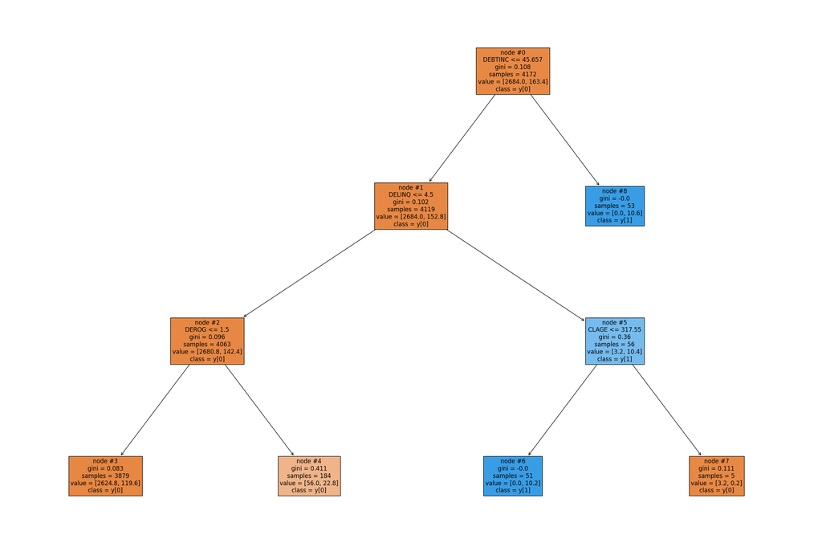

```python
features = list(X.columns)

plt.figure(figsize = (30, 20))

tree.plot_tree(tree_model,  feature_names = features, filled = True, fontsize = 12, node_ids = True, class_names = True)

plt.show()
```

```python
# Importance of features in the tree building

print (pd.DataFrame(tree_model.feature_importances_, columns = ["Imp"], index = X_train.columns).sort_values(by = 'Imp', ascending = False))
```

```
                     Imp
DEBTINC         0.406708
DELINQ          0.297072
DEROG           0.199042
CLAGE           0.097179
LOAN            0.000000
REASON_nan      0.000000
JOB_Self        0.000000
JOB_Sales       0.000000
JOB_ProfExe     0.000000
JOB_Other       0.000000
JOB_Office      0.000000
JOB_Mgr         0.000000
REASON_DebtCon  0.000000
REASON_HomeImp  0.000000
MORTDUE         0.000000
CLNO            0.000000
NINQ            0.000000
YOJ             0.000000
VALUE           0.000000
JOB_nan         0.000000
```

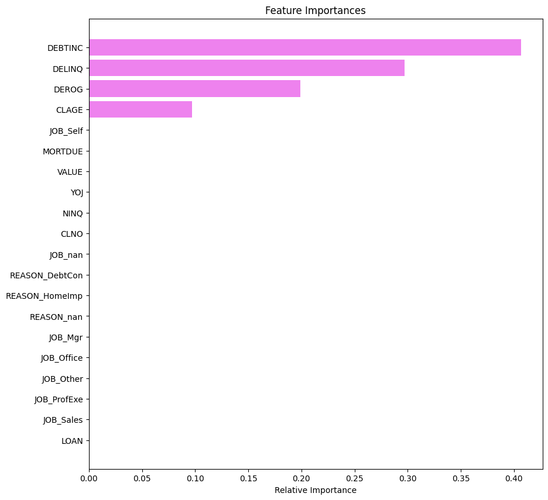

```python
# Plotting the feature importance
importances = tree_model.feature_importances_

indices = np.argsort(importances)

plt.figure(figsize = (10, 10))

plt.title('Feature Importances')

plt.barh(range(len(indices)), importances[indices], color = 'violet', align = 'center')

plt.yticks(range(len(indices)), [features[i] for i in indices])

plt.xlabel('Relative Importance')

plt.show()
```

**Observations:**

Debt to income ration is important as it is required for the institute to roll the money

### **Building a Random Forest Classifier**

**Random Forest is a bagging algorithm where the base models are Decision Trees.** Samples are taken from the training data and on each sample a decision tree makes a prediction.

**The results from all the decision trees are combined together and the final prediction is made using voting or averaging.**

```python
# Fitting the Random Forest classifier on the training data
rf_estimator = RandomForestClassifier(n_estimators=100, random_state = 1)

rf_estimator.fit(X_train, y_train)
```

```
RandomForestClassifier(random_state=1)
```

```python
# Checking performance on the training data
y_pred_train_rf = rf_estimator.predict(X_train)

metrics_score(y_train, y_pred_train_rf)
```

```
              precision    recall  f1-score   support

           0       1.00      1.00      1.00      3355
           1       1.00      1.00      1.00       817

    accuracy                           1.00      4172
   macro avg       1.00      1.00      1.00      4172
weighted avg       1.00      1.00      1.00      4172
```

```
              precision    recall  f1-score   support

           0       0.92      0.98      0.95      1416
           1       0.92      0.68      0.78       372

    accuracy                           0.92      1788
   macro avg       0.92      0.83      0.87      1788
weighted avg       0.92      0.92      0.92      1788
```

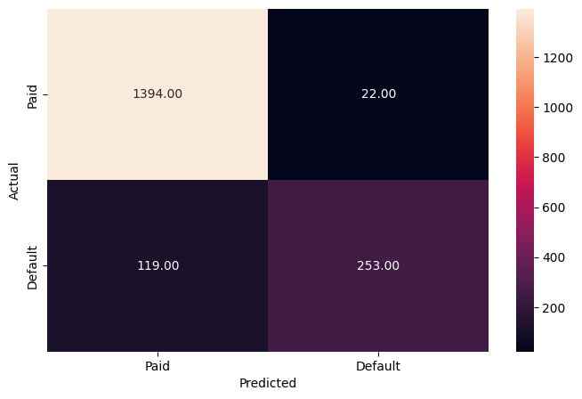

```python
# Checking performance on the testing data
y_pred_test_rf = rf_estimator.predict(X_test)

metrics_score(y_test, y_pred_test_rf)
```

**Observations:**

Random forest is giving us recall result of 0.68

```python
rf_estimator_test = model_performance_classification(rf_estimator,X_test,y_test)
rf_estimator_test
```

|  | Precision | Recall | Accuracy | F1-score |
| --- | --- | --- | --- | --- |
| 1 | 0.920674 | 0.832285 | 0.921141 | 0.866966 |

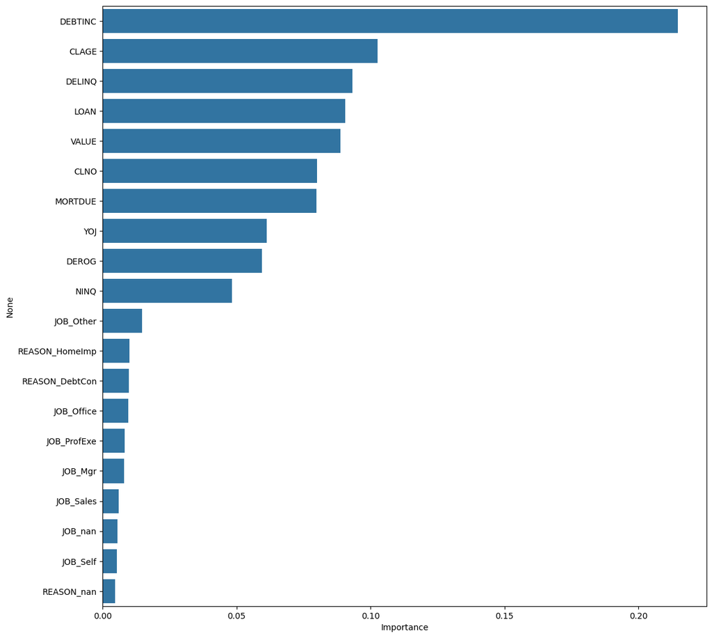

```python
# Plotting feature importance
importances = rf_estimator.feature_importances_

columns = X.columns

importance_df = pd.DataFrame(importances, index = columns, columns = ['Importance']).sort_values(by = 'Importance', ascending = False)

plt.figure(figsize = (13, 13))

sns.barplot(x=importance_df.Importance, y=importance_df.index);
```

### **Random Forest Classifier Hyperparameter Tuning**

```python
# Choose the type of classifier
rf_estimator_tuned = RandomForestClassifier(n_estimators=100, random_state = 1)

# Grid of parameters to choose from
params_rf = {
        "n_estimators": [100, 250, 500],
        "min_samples_leaf": np.arange(1, 4, 1),
        "max_features": [0.7, 0.9, 'auto'],
}


# Type of scoring used to compare parameter combinations - recall score for class 1
scorer = metrics.make_scorer(recall_score, pos_label = 1)

# Run the grid search
grid_obj = GridSearchCV(rf_estimator_tuned, params_rf, scoring = scorer, cv = 5)

grid_obj = grid_obj.fit(X_train, y_train)

# Set the classifier to the best combination of parameters
rf_estimator_tuned = grid_obj.best_estimator_
```

```python
rf_estimator_tuned.fit(X_train, y_train)
```

```
RandomForestClassifier(max_features=0.7, n_estimators=250, random_state=1)
```

```python
# Checking performance on the training data
y_pred_train_rf_tuned = rf_estimator_tuned.predict(X_train)

metrics_score(y_train, y_pred_train_rf_tuned)
```

```
              precision    recall  f1-score   support

           0       1.00      1.00      1.00      3355
           1       1.00      1.00      1.00       817

    accuracy                           1.00      4172
   macro avg       1.00      1.00      1.00      4172
weighted avg       1.00      1.00      1.00      4172
```

```
              precision    recall  f1-score   support

           0       0.92      0.96      0.94      1416
           1       0.83      0.70      0.76       372

    accuracy                           0.91      1788
   macro avg       0.88      0.83      0.85      1788
weighted avg       0.90      0.91      0.90      1788
```

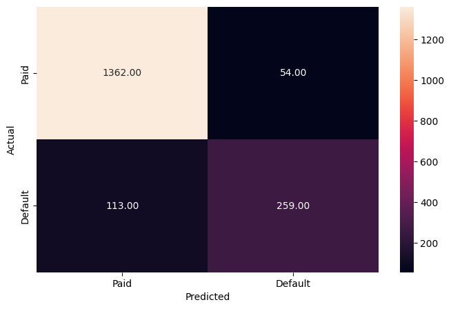

```python
# Checking performance on the test data
y_pred_test_rf_tuned = rf_estimator_tuned.predict(X_test)

metrics_score(y_test, y_pred_test_rf_tuned)
```

**Observations:** After hyper tuning the random forest is only manage to give us the recall of 0.70

```python
rf_estimator_tuned_test = model_performance_classification(rf_estimator_tuned, X_test, y_test)
rf_estimator_tuned_test
```

|  | Precision | Recall | Accuracy | F1-score |
| --- | --- | --- | --- | --- |
| 1 | 0.875433 | 0.82905 | 0.9066 | 0.849219 |

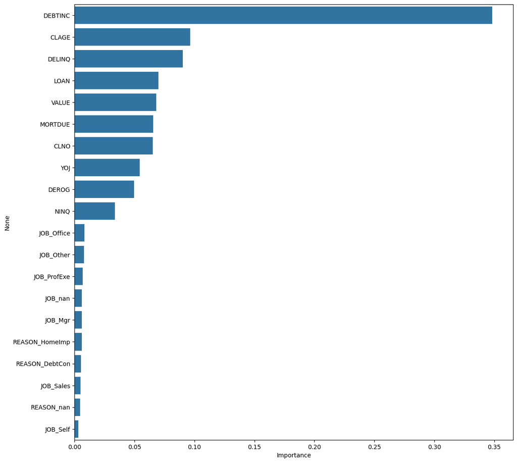

```python
# Plotting feature importance
importances = rf_estimator_tuned.feature_importances_

columns = X.columns

importance_df = pd.DataFrame(importances, index = columns, columns = ['Importance']).sort_values(by = 'Importance', ascending = False)

plt.figure(figsize = (13, 13))

sns.barplot(x=importance_df.Importance, y=importance_df.index);
```

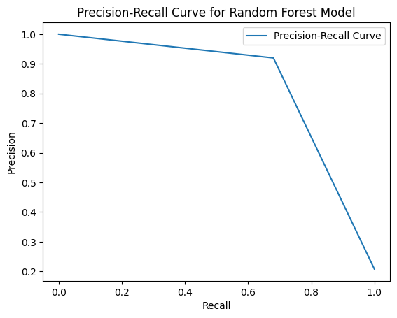

```python
from sklearn.metrics import precision_recall_curve
import matplotlib.pyplot as plt  # For plot customization

# Assuming you have X_test, y_test, and the trained Random Forest model (rf_model)

y_pred = rf_estimator.predict(X_test)

precision, recall, thresholds = precision_recall_curve(y_test, y_pred)


plt.plot(recall, precision, label='Precision-Recall Curve')
plt.xlabel('Recall')
plt.ylabel('Precision')
plt.title('Precision-Recall Curve for Random Forest Model')
plt.legend()
plt.show()
```

```python
# Installing the xgboost library using the 'pip' command
!pip install xgboost
```

```python
# Importing the XGBClassifier from the xgboost library
from xgboost import XGBClassifier
```

```python
# XGBoost Classifier
xgb = XGBClassifier(random_state = 1, eval_metric = 'logloss')

# Fitting the model
xgb.fit(X_train,y_train)

# Model Performance on the test data
xgb_perf_test = model_performance_classification(xgb,X_test,y_test)

xgb_perf_test
```

|  | Precision | Recall | Accuracy | F1-score |
| --- | --- | --- | --- | --- |
| 1 | 0.907227 | 0.847856 | 0.92226 | 0.87308 |

```python
from xgboost import XGBClassifier  # Or XGBRegressor for regression

# Create your XGBoost model
xgb = XGBClassifier()  # Or XGBClassifier for classification, XGBRegressor for regression

param_grid = {
    "learning_rate": [0.01, 0.1, 1],
    "n_estimators": [100, 500, 1000],
    "max_depth": [3, 5, 8],
    "gamma": [0, 0.1, 0.5],
    "reg_alpha": [0, 0.01, 0.1],
    "reg_lambda": [1, 10, 100],
}

# Grid search for exhaustive exploration
grid_search = GridSearchCV(xgb, param_grid)  # Adapt scoring to your metric

grid_search.fit(X_train, y_train)

# Access the best model
best_model = grid_search.best_estimator_
```

```python
xgb_tuned_test = model_performance_classification(grid_search,X_test,y_test)

xgb_tuned_test
```

|  | Precision | Recall | Accuracy | F1-score |
| --- | --- | --- | --- | --- |
| 1 | 0.928899 | 0.870205 | 0.935682 | 0.895469 |

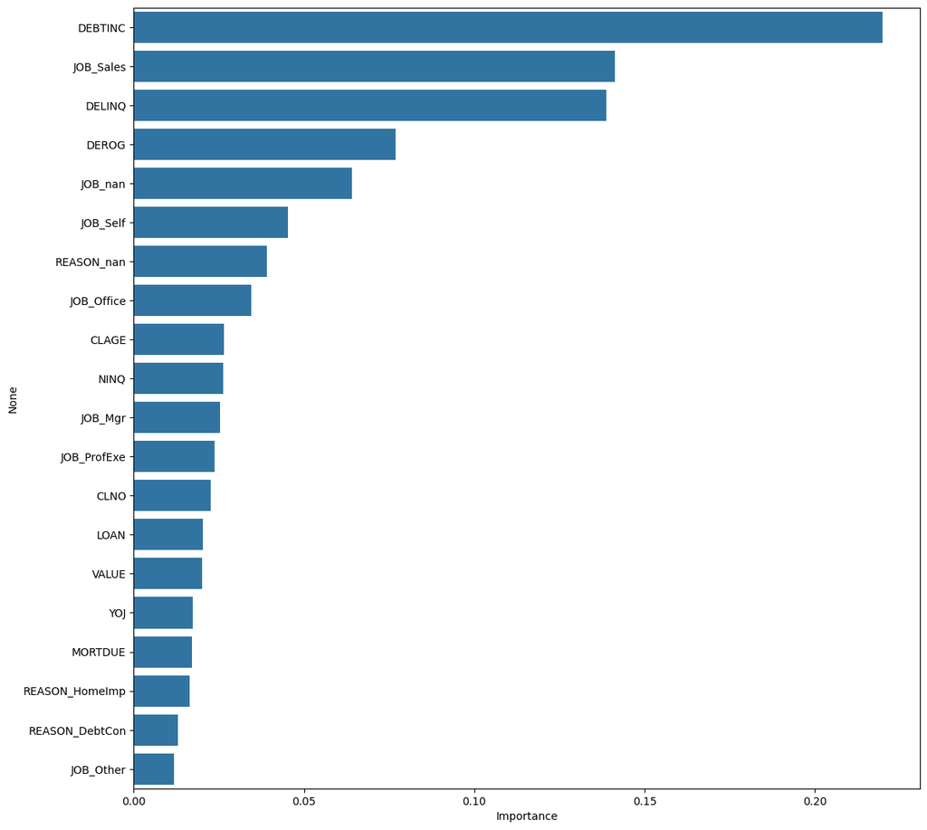

```python
# Plotting feature importance
importances = best_model.feature_importances_

columns = X.columns

importance_df = pd.DataFrame(importances, index = columns, columns = ['Importance']).sort_values(by = 'Importance', ascending = False)

plt.figure(figsize = (13, 13))

sns.barplot(x=importance_df.Importance, y=importance_df.index);
```

```python
models_test_comp_df = pd.concat(

    [

    dtree_test.T, dtree_tuned_test.T,rf_estimator_test.T,
    rf_estimator_tuned_test.T,  xgb_perf_test.T,xgb_tuned_test.T
    ],

    axis = 1,
)

models_test_comp_df.columns = [

    "Decision Tree classifier",
    "Tuned Decision Tree classifier",
    "Random Forest classifier",
    "Tuned Random Forest classifier",
    "XGBoost classifier",
    "Tuned XGBoost Classifier"
]

print("Test performance comparison:")
```

```
Test performance comparison:
```

```python
models_test_comp_df
```

|  | Decision Tree classifier | Tuned Decision Tree classifier | Random Forest classifier | Tuned Random Forest classifier | XGBoost classifier | Tuned XGBoost Classifier |
| --- | --- | --- | --- | --- | --- | --- |
| Precision | 0.806869 | 0.739148 | 0.920674 | 0.875433 | 0.907227 | 0.928899 |
| Recall | 0.781609 | 0.807875 | 0.832285 | 0.829050 | 0.847856 | 0.870205 |
| Accuracy | 0.869128 | 0.816555 | 0.921141 | 0.906600 | 0.922260 | 0.935682 |
| F1-score | 0.793069 | 0.759650 | 0.866966 | 0.849219 | 0.873080 | 0.895469 |

#### **Milestone**

**1. Comparison of various techniques and their relative performance based on chosen Metric (Measure of success):**

- How do different techniques perform? Which one is performing relatively better? Is there scope to improve the performance further?

**2. Refined insights:**

- What are the most meaningful insights relevant to the problem?

Missing data and outliers are important problem to adddress

**3. Proposal for the final solution design:**

- What model do you propose to be adopted? Why is this the best solution to adopt?